# Year of interview

# 1 Description of DataSchema variable

The description of harmonised variable is the following:

- Short name: `yintw`
- Variable label: `Year of interview`
- Variable description: `Year of interview`
- Domain: `Other administrative variables`
- Value type: `Continuous`
- Category missings:

| **Code** | **Category Label** |
| --- | --- |
| 991 | CAPI/interviewer error |
| 992 | Impute |
| 993 | Disable to measure |
| 994 | Not attempt/not done |
| 995 | Does not answer |
| 996 | Not applicable |
| 997 | Refuse |
| 998 | Do not know |
| 999 | Missing |

# 2 Data process

## 2.1 England

### 2.1.1 Wave 1

#### 2.1.1.1 Study-specific variable description

| **Name** | `iintdaty` |
| --- | --- |
| **Label** | `Year of Individual Interview: Year of date: TODAYS DATE` |
| **Table name** | `wave_1_ifs_derived_variables` |
| **Type of variable** | `date` |
| **Description** |  |

iintdaty

| Sample size | Missing values |
| --- | --- |
| 12099 | 0 |

Category

|  | 2002 | 2003 |
| --- | --- | --- |
| Frequency | 10585.00 | 1514.00 |
| Percentage | 87.49 | 12.51 |

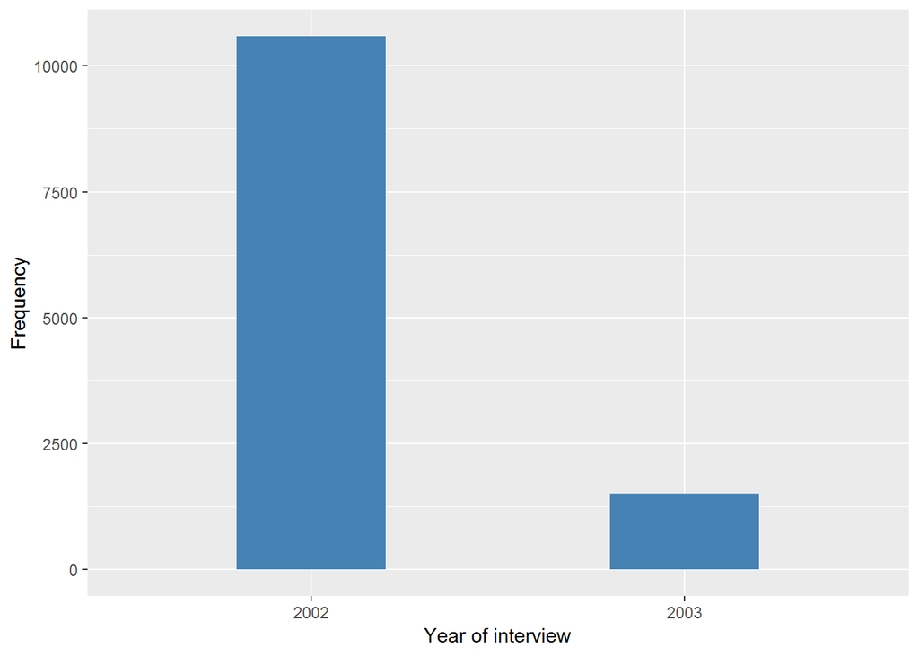

#### 2.1.1.2 Harmonisation algorithm

The harmonized variable is the same of the study-specific variable but the missing values have to be recoded as follows:

- `NA into 999`

**R script:**

```r
ELSA_ds_w1 <- tibble(id = ELSA_w1$id)
ELSA_ds_w1$yintw <- as.numeric(ELSA_w1$iintdaty)
ELSA_ds_w1$yintw <- labelled(ELSA_ds_w1$yintw, labels = c(Missing = 999, `Do not know` = 998,
    Refuse = 997, `Not applicable` = 996, `Does not answer` = 995, `Not attempt not done` = 994,
    `Disable to measure` = 993, Impute = 992, `CAPI interviewer error` = 991))
```

#### 2.1.1.3 Statistics of the new harmonised variable

Year of interview

| Sample size | Missing values |
| --- | --- |
| 12099 | 0 |

Category

|  | 2002 | 2003 |
| --- | --- | --- |
| Frequency | 10585.00 | 1514.00 |
| Percentage | 87.49 | 12.51 |

Type of missing

|  | 991 | 992 | 993 | 994 | 995 | 996 | 997 | 998 | 999 | NA |
| --- | --- | --- | --- | --- | --- | --- | --- | --- | --- | --- |
| Frequency | 0 | 0 | 0 | 0 | 0 | 0 | 0 | 0 | 0 | 0 |
| Percentage | 0 | 0 | 0 | 0 | 0 | 0 | 0 | 0 | 0 | 0 |

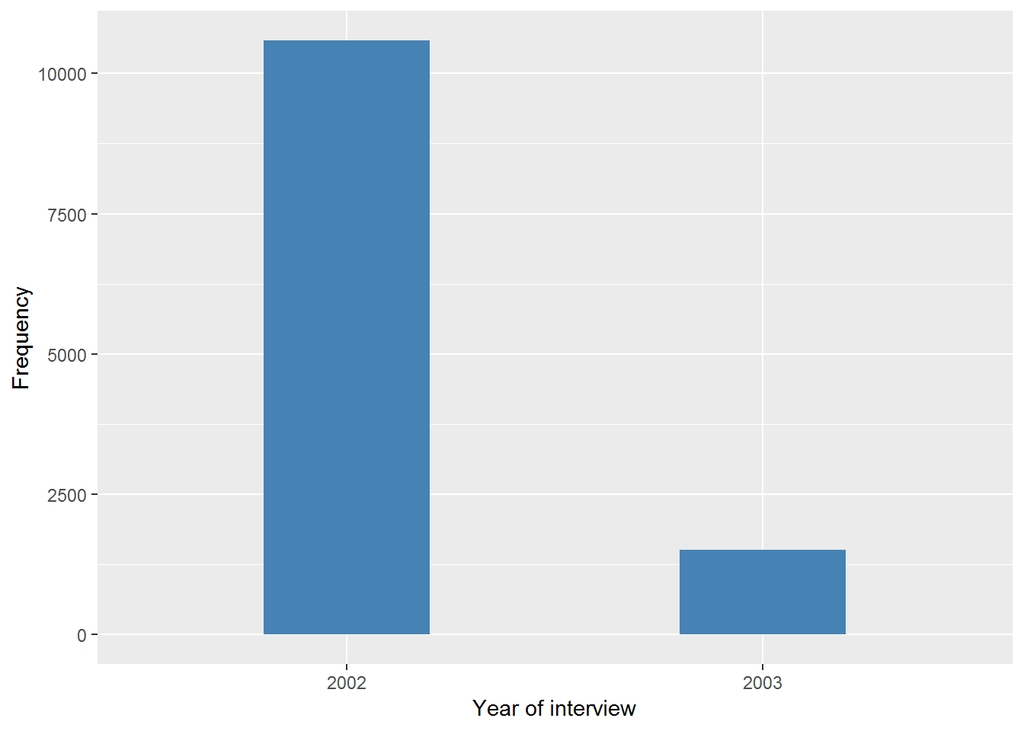

#### 2.1.1.4 Validation

|  | 2002 | 2003 |
| --- | --- | --- |
| BeforeH | 10585 | 1514 |
| AfterH | 10585 | 1514 |

### 2.1.2 Wave 2

#### 2.1.2.1 Study-specific variable description

| **Name** | `iintdaty` |
| --- | --- |
| **Label** | `Year of Individual Interview` |
| **Table name** | `wave_2_ifs_derived_variables` |
| **Type of variable** | `date` |
| **Description** |  |

iintdaty

| Sample size | Missing values |
| --- | --- |
| 9432 | 0 |

Category

|  | 2004 | 2005 |
| --- | --- | --- |
| Frequency | 5240.00 | 4192.00 |
| Percentage | 55.56 | 44.44 |

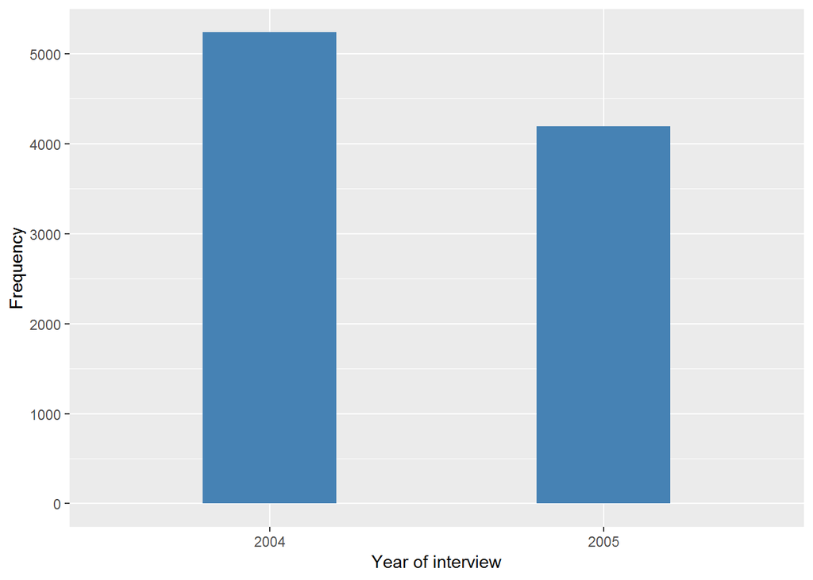

#### 2.1.2.2 Harmonisation algorithm

The harmonized variable is the same of the study-specific variable but the missing values have to be recoded as follows:

- `NA into 999`

**R script:**

```r
ELSA_ds_w2 <- tibble(id = ELSA_w2$id)
ELSA_ds_w2$yintw <- as.numeric(ELSA_w2$iintdaty)
ELSA_ds_w2$yintw <- labelled(ELSA_ds_w2$yintw, labels = c(Missing = 999, `Do not know` = 998,
    Refuse = 997, `Not applicable` = 996, `Does not answer` = 995, `Not attempt not done` = 994,
    `Disable to measure` = 993, Impute = 992, `CAPI interviewer error` = 991))
```

#### 2.1.2.3 Statistics of the new harmonised variable

Year of interview

| Sample size | Missing values |
| --- | --- |
| 9432 | 0 |

Category

|  | 2004 | 2005 |
| --- | --- | --- |
| Frequency | 5240.00 | 4192.00 |
| Percentage | 55.56 | 44.44 |

Type of missing

|  | 991 | 992 | 993 | 994 | 995 | 996 | 997 | 998 | 999 | NA |
| --- | --- | --- | --- | --- | --- | --- | --- | --- | --- | --- |
| Frequency | 0 | 0 | 0 | 0 | 0 | 0 | 0 | 0 | 0 | 0 |
| Percentage | 0 | 0 | 0 | 0 | 0 | 0 | 0 | 0 | 0 | 0 |

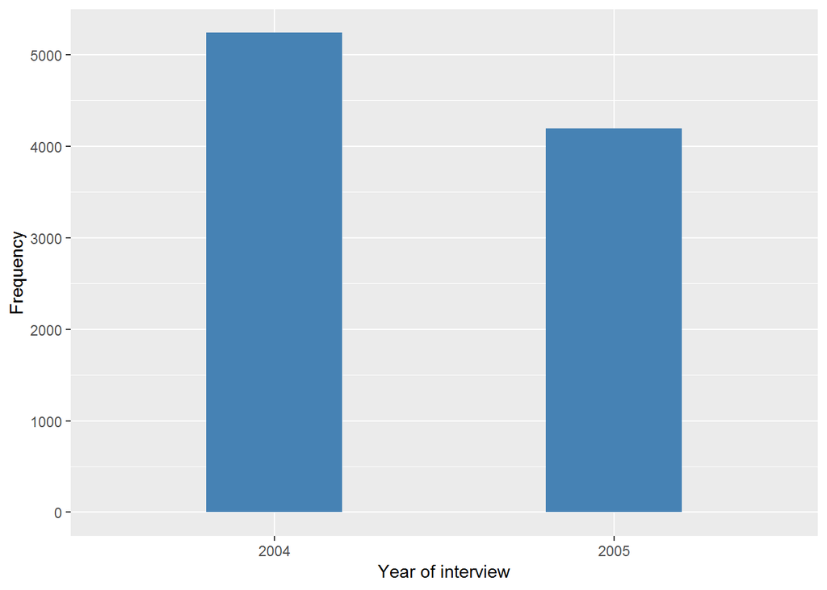

#### 2.1.2.4 Validation

|  | 2004 | 2005 |
| --- | --- | --- |
| BeforeH | 5240 | 4192 |
| AfterH | 5240 | 4192 |

### 2.1.3 Wave 3

#### 2.1.3.1 Study-specific variable description

| **Name** | `iintdaty` |
| --- | --- |
| **Label** | `Year of Individual Interview: Year of date: TODAYS DATE` |
| **Table name** | `wave_3_ifs_derived_variables` |
| **Type of variable** | `date` |
| **Description** |  |

iintdaty

| Sample size | Missing values |
| --- | --- |
| 9771 | 0 |

Category

|  | 2006 | 2007 |
| --- | --- | --- |
| Frequency | 8099.00 | 1672.00 |
| Percentage | 82.89 | 17.11 |

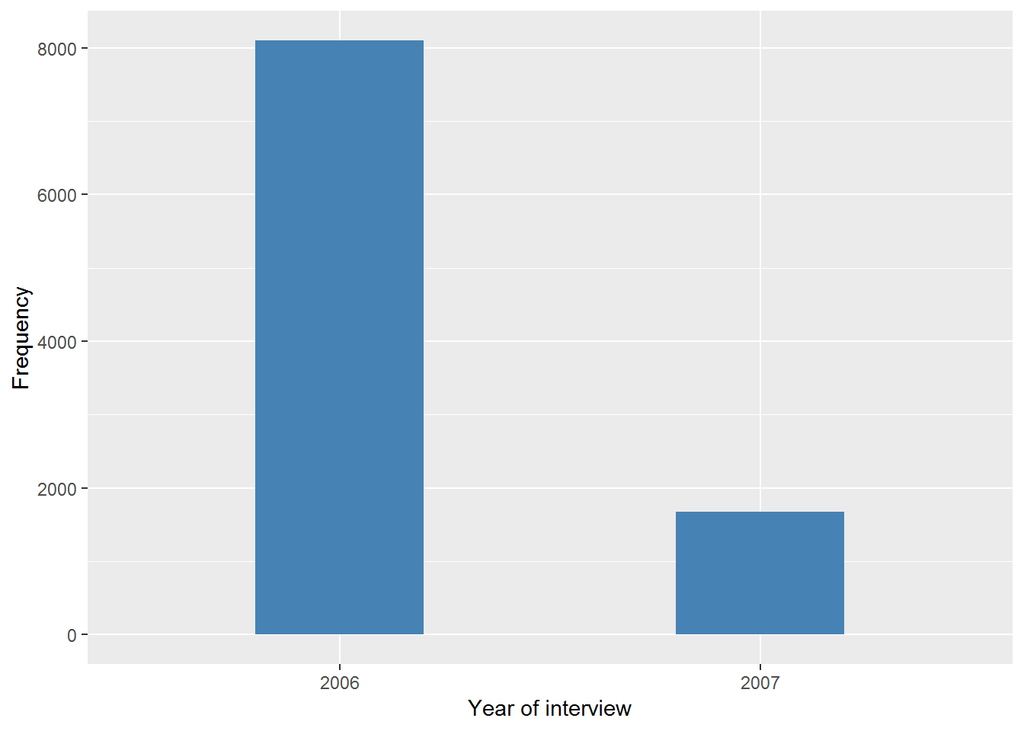

#### 2.1.3.2 Harmonisation algorithm

The harmonized variable is the same of the study-specific variable but the missing values have to be recoded as follows:

- `NA into 999`

**R script:**

```r
ELSA_ds_w3 <- tibble(id = ELSA_w3$id)
ELSA_ds_w3$yintw <- as.numeric(ELSA_w3$iintdaty)
ELSA_ds_w3$yintw <- labelled(ELSA_ds_w3$yintw, labels = c(Missing = 999, `Do not know` = 998,
    Refuse = 997, `Not applicable` = 996, `Does not answer` = 995, `Not attempt not done` = 994,
    `Disable to measure` = 993, Impute = 992, `CAPI interviewer error` = 991))
```

#### 2.1.3.3 Statistics of the new harmonised variable

Year of interview

| Sample size | Missing values |
| --- | --- |
| 9771 | 0 |

Category

|  | 2006 | 2007 |
| --- | --- | --- |
| Frequency | 8099.00 | 1672.00 |
| Percentage | 82.89 | 17.11 |

Type of missing

|  | 991 | 992 | 993 | 994 | 995 | 996 | 997 | 998 | 999 | NA |
| --- | --- | --- | --- | --- | --- | --- | --- | --- | --- | --- |
| Frequency | 0 | 0 | 0 | 0 | 0 | 0 | 0 | 0 | 0 | 0 |
| Percentage | 0 | 0 | 0 | 0 | 0 | 0 | 0 | 0 | 0 | 0 |

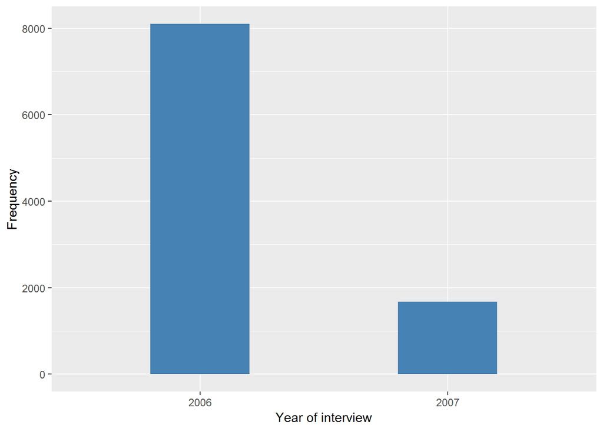

#### 2.1.3.4 Validation

|  | 2006 | 2007 |
| --- | --- | --- |
| BeforeH | 8099 | 1672 |
| AfterH | 8099 | 1672 |

### 2.1.4 Wave 4

#### 2.1.4.1 Study-specific variable description

| **Name** | `iintdaty` |
| --- | --- |
| **Label** | `Year of Individual Interview: Year of date: TODAYS DATE` |
| **Table name** | `wave_4_ifs_derived_variables` |
| **Type of variable** | `date` |
| **Description** |  |

iintdaty

| Sample size | Missing values |
| --- | --- |
| 11050 | 0 |

Category

|  | 2008 | 2009 |
| --- | --- | --- |
| Frequency | 7127.0 | 3923.0 |
| Percentage | 64.5 | 35.5 |

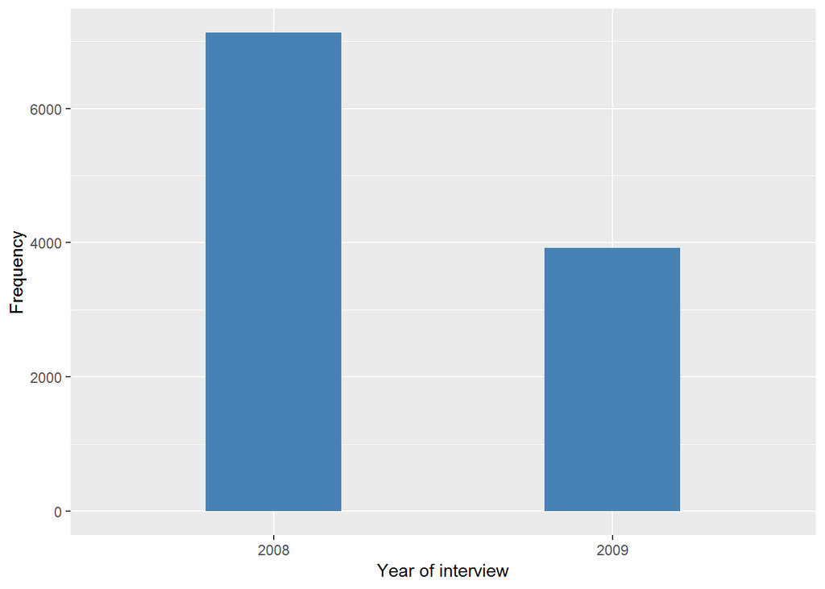

#### 2.1.4.2 Harmonisation algorithm

The harmonized variable is the same of the study-specific variable but the missing values have to be recoded as follows:

- `NA into 999`

**R script:**

```r
ELSA_ds_w4 <- tibble(id = ELSA_w4$id)
ELSA_ds_w4$yintw <- as.numeric(ELSA_w4$iintdaty)
ELSA_ds_w4$yintw <- labelled(ELSA_ds_w4$yintw, labels = c(Missing = 999, `Do not know` = 998,
    Refuse = 997, `Not applicable` = 996, `Does not answer` = 995, `Not attempt not done` = 994,
    `Disable to measure` = 993, Impute = 992, `CAPI interviewer error` = 991))
```

#### 2.1.4.3 Statistics of the new harmonised variable

Year of interview

| Sample size | Missing values |
| --- | --- |
| 11050 | 0 |

Category

|  | 2008 | 2009 |
| --- | --- | --- |
| Frequency | 7127.0 | 3923.0 |
| Percentage | 64.5 | 35.5 |

Type of missing

|  | 991 | 992 | 993 | 994 | 995 | 996 | 997 | 998 | 999 | NA |
| --- | --- | --- | --- | --- | --- | --- | --- | --- | --- | --- |
| Frequency | 0 | 0 | 0 | 0 | 0 | 0 | 0 | 0 | 0 | 0 |
| Percentage | 0 | 0 | 0 | 0 | 0 | 0 | 0 | 0 | 0 | 0 |

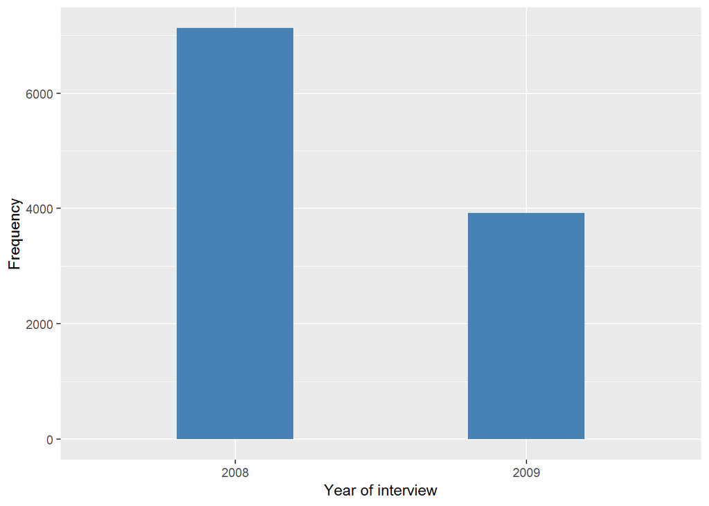

#### 2.1.4.4 Validation

|  | 2008 | 2009 |
| --- | --- | --- |
| BeforeH | 7127 | 3923 |
| AfterH | 7127 | 3923 |

### 2.1.5 Wave 5

#### 2.1.5.1 Study-specific variable description

| **Name** | `iintdaty` |
| --- | --- |
| **Label** | `Year of Individual Interview: Year of date: TODAYS DATE` |
| **Table name** | `wave_5_ifs_derived_variables` |
| **Type of variable** | `date` |
| **Description** |  |

iintdaty

| Sample size | Missing values |
| --- | --- |
| 10274 | 0 |

Category

|  | 2010 | 2011 |
| --- | --- | --- |
| Frequency | 7066.00 | 3208.00 |
| Percentage | 68.78 | 31.22 |

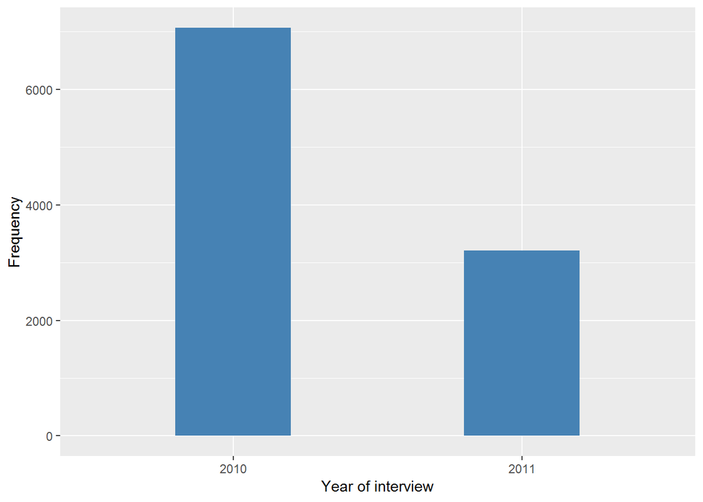

#### 2.1.5.2 Harmonisation algorithm

The harmonized variable is the same of the study-specific variable but the missing values have to be recoded as follows:

- `NA into 999`

**R script:**

```r
ELSA_ds_w5 <- tibble(id = ELSA_w5$id)
ELSA_ds_w5$yintw <- as.numeric(ELSA_w5$iintdaty)
ELSA_ds_w5$yintw <- labelled(ELSA_ds_w5$yintw, labels = c(Missing = 999, `Do not know` = 998,
    Refuse = 997, `Not applicable` = 996, `Does not answer` = 995, `Not attempt not done` = 994,
    `Disable to measure` = 993, Impute = 992, `CAPI interviewer error` = 991))
```

#### 2.1.5.3 Statistics of the new harmonised variable

Year of interview

| Sample size | Missing values |
| --- | --- |
| 10274 | 0 |

Category

|  | 2010 | 2011 |
| --- | --- | --- |
| Frequency | 7066.00 | 3208.00 |
| Percentage | 68.78 | 31.22 |

Type of missing

|  | 991 | 992 | 993 | 994 | 995 | 996 | 997 | 998 | 999 | NA |
| --- | --- | --- | --- | --- | --- | --- | --- | --- | --- | --- |
| Frequency | 0 | 0 | 0 | 0 | 0 | 0 | 0 | 0 | 0 | 0 |
| Percentage | 0 | 0 | 0 | 0 | 0 | 0 | 0 | 0 | 0 | 0 |

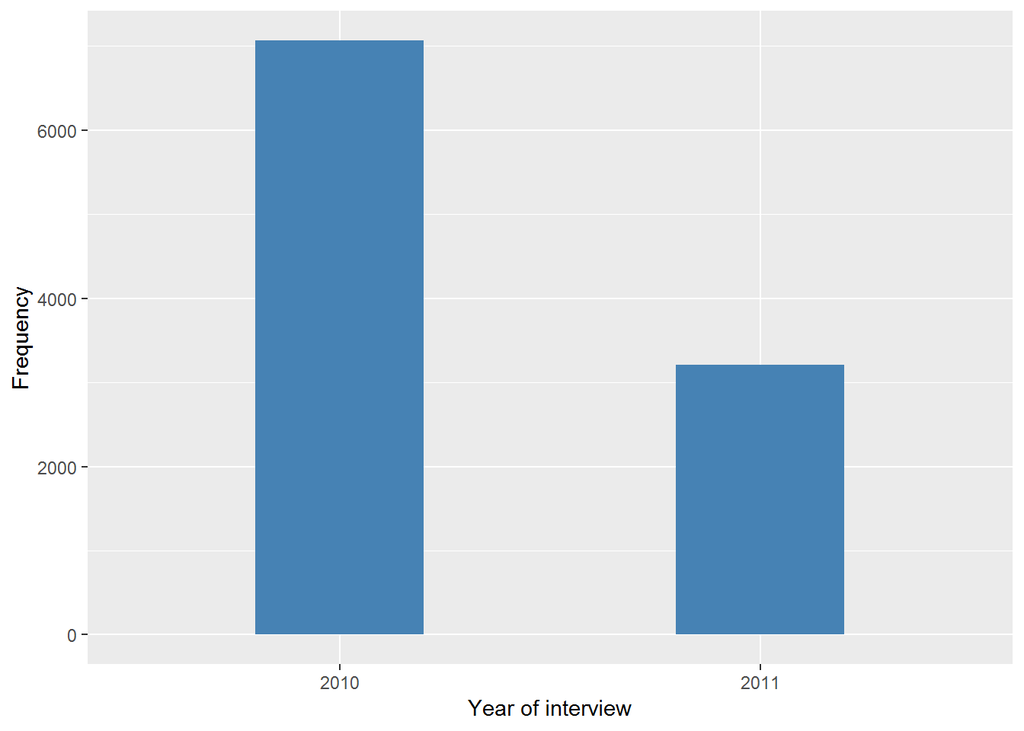

#### 2.1.5.4 Validation

|  | 2010 | 2011 |
| --- | --- | --- |
| BeforeH | 7066 | 3208 |
| AfterH | 7066 | 3208 |

### 2.1.6 Wave 6

#### 2.1.6.1 Study-specific variable description

| **Name** | `iintdaty` |
| --- | --- |
| **Label** | `Year of Individual Interview: Year of date: TODAYS DATE` |
| **Table name** | `wave_6_ifs_derived_variables` |
| **Type of variable** | `date` |
| **Description** |  |

iintdaty

| Sample size | Missing values |
| --- | --- |
| 10601 | 0 |

Category

|  | 2012 | 2013 |
| --- | --- | --- |
| Frequency | 9047.00 | 1554.00 |
| Percentage | 85.34 | 14.66 |

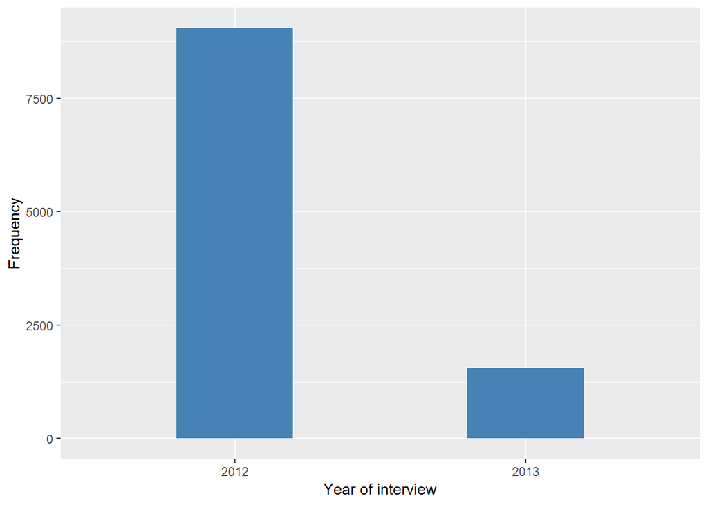

#### 2.1.6.2 Harmonisation algorithm

The harmonized variable is the same of the study-specific variable but the missing values have to be recoded as follows:

- `NA into 999`

**R script:**

```r
ELSA_ds_w6 <- tibble(id = ELSA_w6$id)
ELSA_ds_w6$yintw <- as.numeric(ELSA_w6$iintdaty)
ELSA_ds_w6$yintw <- labelled(ELSA_ds_w6$yintw, labels = c(Missing = 999, `Do not know` = 998,
    Refuse = 997, `Not applicable` = 996, `Does not answer` = 995, `Not attempt not done` = 994,
    `Disable to measure` = 993, Impute = 992, `CAPI interviewer error` = 991))
```

#### 2.1.6.3 Statistics of the new harmonised variable

Year of interview

| Sample size | Missing values |
| --- | --- |
| 10601 | 0 |

Category

|  | 2012 | 2013 |
| --- | --- | --- |
| Frequency | 9047.00 | 1554.00 |
| Percentage | 85.34 | 14.66 |

Type of missing

|  | 991 | 992 | 993 | 994 | 995 | 996 | 997 | 998 | 999 | NA |
| --- | --- | --- | --- | --- | --- | --- | --- | --- | --- | --- |
| Frequency | 0 | 0 | 0 | 0 | 0 | 0 | 0 | 0 | 0 | 0 |
| Percentage | 0 | 0 | 0 | 0 | 0 | 0 | 0 | 0 | 0 | 0 |

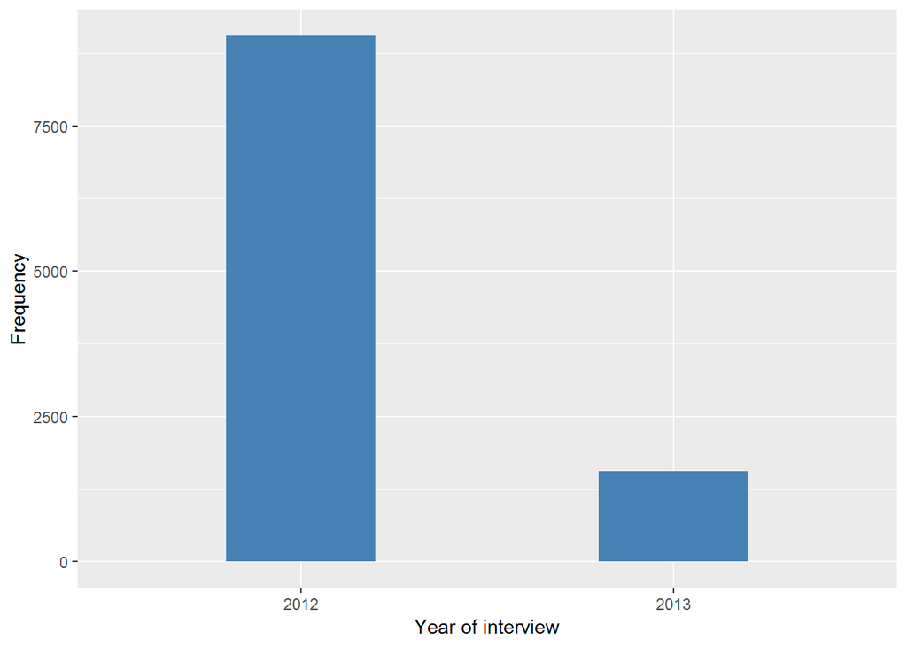

#### 2.1.6.4 Validation

|  | 2012 | 2013 |
| --- | --- | --- |
| BeforeH | 9047 | 1554 |
| AfterH | 9047 | 1554 |

### 2.1.7 Wave 7

#### 2.1.7.1 Study-specific variable description

| **Name** | `iintdaty` |
| --- | --- |
| **Label** | `Year of Individual Interview` |
| **Table name** | `wave7_dv` |
| **Type of variable** | `date` |
| **Description** |  |

iintdaty

| Sample size | Missing values |
| --- | --- |
| 9666 | 0 |

Category

|  | 2014 | 2015 |
| --- | --- | --- |
| Frequency | 7695.00 | 1971.00 |
| Percentage | 79.61 | 20.39 |

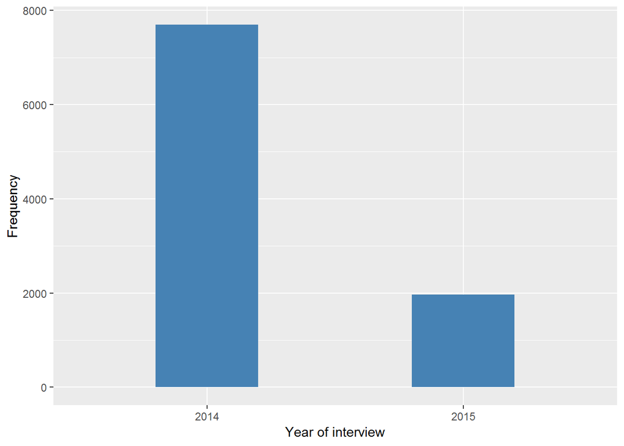

#### 2.1.7.2 Harmonisation algorithm

The harmonized variable is the same of the study-specific variable but the missing values have to be recoded as follows:

- `NA into 999`

**R script:**

```r
ELSA_ds_w7 <- tibble(id = ELSA_w7$id)
ELSA_ds_w7$yintw <- as.numeric(ELSA_w7$iintdaty)
ELSA_ds_w7$yintw <- labelled(ELSA_ds_w7$yintw, labels = c(Missing = 999, `Do not know` = 998,
    Refuse = 997, `Not applicable` = 996, `Does not answer` = 995, `Not attempt not done` = 994,
    `Disable to measure` = 993, Impute = 992, `CAPI interviewer error` = 991))
```

#### 2.1.7.3 Statistics of the new harmonised variable

Year of interview

| Sample size | Missing values |
| --- | --- |
| 9666 | 0 |

Category

|  | 2014 | 2015 |
| --- | --- | --- |
| Frequency | 7695.00 | 1971.00 |
| Percentage | 79.61 | 20.39 |

Type of missing

|  | 991 | 992 | 993 | 994 | 995 | 996 | 997 | 998 | 999 | NA |
| --- | --- | --- | --- | --- | --- | --- | --- | --- | --- | --- |
| Frequency | 0 | 0 | 0 | 0 | 0 | 0 | 0 | 0 | 0 | 0 |
| Percentage | 0 | 0 | 0 | 0 | 0 | 0 | 0 | 0 | 0 | 0 |

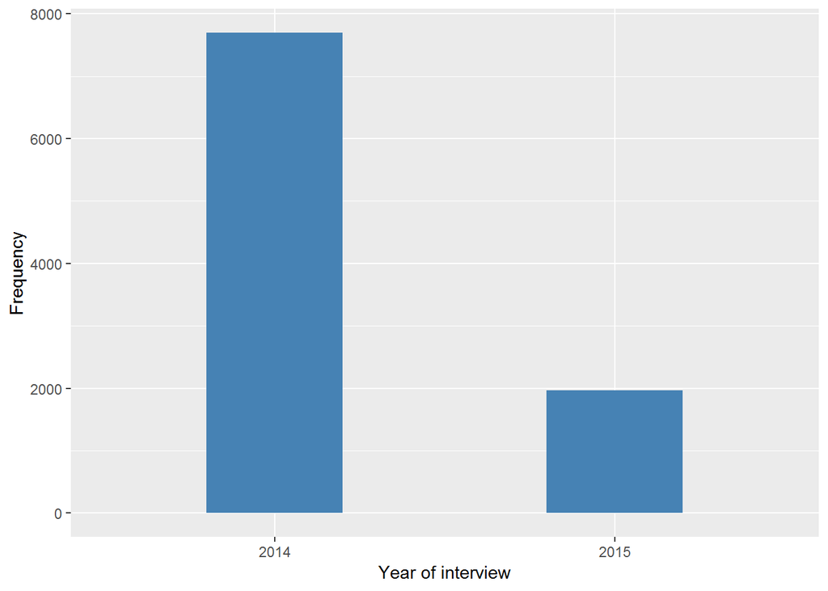

#### 2.1.7.4 Validation

|  | 2014 | 2015 |
| --- | --- | --- |
| BeforeH | 7695 | 1971 |
| AfterH | 7695 | 1971 |

## 2.2 Summary of descriptive statistics of the harmonised variable accross populations and waves

Year of interview

| yintw | W1 | W2 | W3 | W4 | W5 | W6 | W7 |
| --- | --- | --- | --- | --- | --- | --- | --- |
| Min. | 2002 | 2004 | 2006 | 2008 | 2010 | 2012 | 2014 |
| 1st Qu. | 2002 | 2004 | 2006 | 2008 | 2010 | 2012 | 2014 |
| Median | 2002 | 2004 | 2006 | 2008 | 2010 | 2012 | 2014 |
| Mean | 2002 | 2004 | 2006 | 2008 | 2010 | 2012 | 2014 |
| 3rd Qu. | 2002 | 2005 | 2006 | 2009 | 2011 | 2012 | 2014 |
| Max. | 2003 | 2005 | 2007 | 2009 | 2011 | 2013 | 2015 |
| No-missings | 12099 | 9432 | 9771 | 11050 | 10274 | 10601 | 9666 |
| 991 | 0 | 0 | 0 | 0 | 0 | 0 | 0 |
| 992 | 0 | 0 | 0 | 0 | 0 | 0 | 0 |
| 993 | 0 | 0 | 0 | 0 | 0 | 0 | 0 |
| 994 | 0 | 0 | 0 | 0 | 0 | 0 | 0 |
| 995 | 0 | 0 | 0 | 0 | 0 | 0 | 0 |
| 996 | 0 | 0 | 0 | 0 | 0 | 0 | 0 |
| 997 | 0 | 0 | 0 | 0 | 0 | 0 | 0 |
| 998 | 0 | 0 | 0 | 0 | 0 | 0 | 0 |
| 999 | 0 | 0 | 0 | 0 | 0 | 0 | 0 |
| NA | 0 | 0 | 0 | 0 | 0 | 0 | 0 |
| sample size | 12099 | 9432 | 9771 | 11050 | 10274 | 10601 | 9666 |

# 3 Quality estimation

The date was the same as the study specific variable taking into account the wave time lapse information.